# Report: Exploratory Data Analysis in Action - EDA: Number of attacks

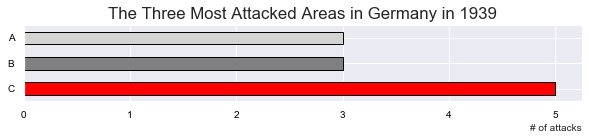

```
A:  "HAMBURG, BREMEN" , 3 Attacks
B:  "BORKUM, SYLT" , 3 Attacks
C:  "SYLT, BORKUM, NORDERNEY" , 5 Attacks
```

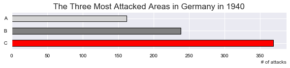

```
A:  COLOGNE , 162 Attacks
B:  HAMBURG , 238 Attacks
C:  BERLIN , 369 Attacks
```

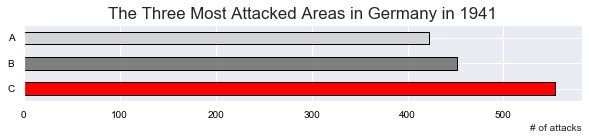

```
A:  HAMBURG , 422 Attacks
B:  BREMEN , 452 Attacks
C:  COLOGNE , 554 Attacks
```

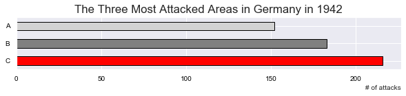

```
A:  DUISBURG , 152 Attacks
B:  BREMEN , 183 Attacks
C:  ESSEN , 216 Attacks
```

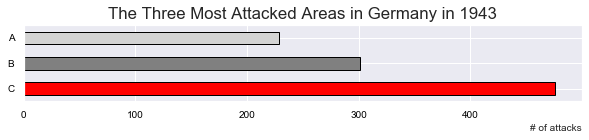

```
A:  KIEL , 229 Attacks
B:  WILHELMSHAVEN , 301 Attacks
C:  BREMEN , 476 Attacks
```

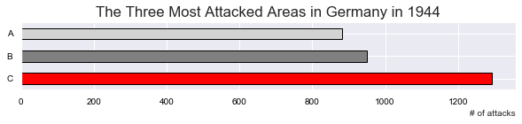

```
A:  KASSEL , 883 Attacks
B:  MERSEBURG , 949 Attacks
C:  BERLIN , 1294 Attacks
```

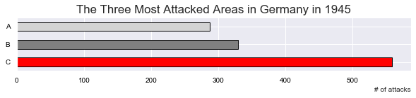

```
A:  HAMBURG , 287 Attacks
B:  MAGDEBURG , 329 Attacks
C:  BERLIN , 559 Attacks
```

```python
def num_attacks4_2(x=1939,y=1945):
    target_location=["GERMANY"]
    attack_year=range(x,y+1)

    for i in attack_year:

        ### Get the three biggest values in year i
        df_noa_year_subset = df_noa.loc[(df_noa['Target Country'].isin(target_location)) & (df_noa.year == int(i))]
        df = df_noa_year_subset.groupby(['Target City'])['Target City'].count().nlargest(3)

        w = 100 # Width of yl-a

        ### Draw a graph
        ax = plt.axes()
        df.plot(kind='barh', figsize=(10,1.4), edgecolor='black', color=['red', 'grey', 'lightgrey'])
        plt.title("The Three Most Attacked Areas in Germany in "+str(i))
        plt.ylabel("")
        plt.xlabel("# of attacks", horizontalalignment='right', x=1.0, fontsize=10)
        ax.tick_params(axis="y", labelcolor="black", labelsize=10)
        ax.tick_params(axis="x", labelcolor="black", labelsize=10)
        ax.set_yticklabels(['C', 'B', 'A'])
        plt.show()

        ### Complementing information
        attacked_DE_city_year = df_noa_year_subset.groupby(['Target City'])['Target City'].count().idxmax()
        print("A: ", df.index[2], ",", df.iloc[2], "Attacks",
              "\nB: ",df.index[1], ",", df.iloc[1], "Attacks")
        print(color.RED +"C: ",df.index[0], ",", df.iloc[0], "Attacks","\n\n" +color.END)
    pass


num_attacks4_2(1939, 1945)
```

**Plot one graph: Most attacked cities**

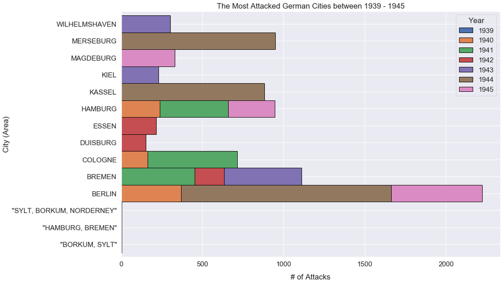

```python
## Graph
df = num_attacks4()

pivot_df = df.pivot(index='City', columns='Year', values='Attacks')
sns.set(font_scale=1.4)
pivot_df.plot(kind='barh',
              stacked=True,
              figsize=(15,10),
              title='The Most Attacked German Cities between 1939 - 1945',
              width=1,
              edgecolor='black',
              legend=True)
plt.ylabel('City (Area)')
plt.xlabel("# of Attacks", labelpad=14)
```

## Summary

In this project we explored the [*Arial Bombing Data Set*](https://www.kaggle.com/usaf/world-war-ii) and applied techniques referred to as **Exploratory Data Analysis**. We could answer the following questions:

> **Q1: How many attacks were launched between 1939 and 1945 over Europe?**

```python
print(Q1)
```

```
Between 1939 and 1945 there were 120,068 attacks launched over Europe.
```

> **Q2: Which Allied Force was responsible for the most of the attacks? Did this change over time?**

```python
print(Q2)
print("\nChanges over time can be confirmed.")
```

```
USA was the country of the allied forces, which was responsible for the most attacks (43,095) between 1939 and 1945.

Changes over time can be confirmed.
```

> **Q3: Which Allied Force launched the most attacks against Germany?**

```python
print(Q3)
```

```
Great Britain was the country of the allied forces, which launched the most attacks against Germany in WW2.
```

> **Q4: Is there a seasonal pattern in the attacks of the Allied Forces against Germany (e.g. winter vs. summer)?**

```python
print(Q4)
```

```
The most attacks against Germany by the allied forces where during summer and the least attacks where during winter.
```

> **Q5: Which area in Germany experienced the highest number of attacks? Did the area change over time?**

```python
print(Q5)
print("\nChanges over time can be confirmed.")
```

```
During WW2, Berlin was the city (area) in Germany that received the most attacks.

Changes over time can be confirmed.
```